# Breast Cancer Prediction

Rohit

December 7, 2017

## Using Breast Cancer(Wisconsin) Diagnostic data set for predictive analysis

The dataset is available on Kaggle (https://www.kaggle.com/uciml/breast-cancer-wisconsin-data.

## Load the requried Libraries

```r
library(dplyr)
library(ggplot2)
library(corrplot)
library(gridExtra)
library(lattice)
library(C50)
library(caret)
library(purrr)
library(ggfortify)
library(gmodels)
library(nnet)
library(vcd)
library(NeuralNetTools)
```

## Read the data

```r
cancer_data <- read.csv("~/Desktop/BreastCancer/Research/data.csv")
```

## Understand the dataset and get it corrected

Before doing any analysis lets check for the missing values in the columns

```r
map_int(cancer_data, function(.x) sum(is.na(.x)))
```

```
##                      id               diagnosis             radius_mean
##                       0                       0                       0
##            texture_mean          perimeter_mean               area_mean
##                       0                       0                       0
##         smoothness_mean        compactness_mean          concavity_mean
##                       0                       0                       0
##     concave.points_mean           symmetry_mean  fractal_dimension_mean
##                       0                       0                       0
##               radius_se              texture_se            perimeter_se
##                       0                       0                       0
##                 area_se           smoothness_se          compactness_se
##                       0                       0                       0
##            concavity_se       concave.points_se             symmetry_se
##                       0                       0                       0
##    fractal_dimension_se            radius_worst           texture_worst
##                       0                       0                       0
##         perimeter_worst              area_worst        smoothness_worst
##                       0                       0                       0
##       compactness_worst         concavity_worst    concave.points_worst
##                       0                       0                       0
##          symmetry_worst fractal_dimension_worst                       X
##                       0                       0                     569
```

```r
#As per the result column 'X' is the only column which has the value 'NA'.
#This check is defintely most important step before starting analysis.
```

Get the dataset corrected by removing the ‘X’ column as it is the only column containing ‘NA’ values and also ‘id’ column as it represents the patient identifier and not required for the analysis.

```r
cancer_data<- cancer_data[,-c(1,33)]
dim(cancer_data)
```

```
## [1] 569  31
```

```r
# We will now perform the analysis on 31 columns
```

## Find correlation

For any analysis to be robust it is good to remove highly correlated predictors.

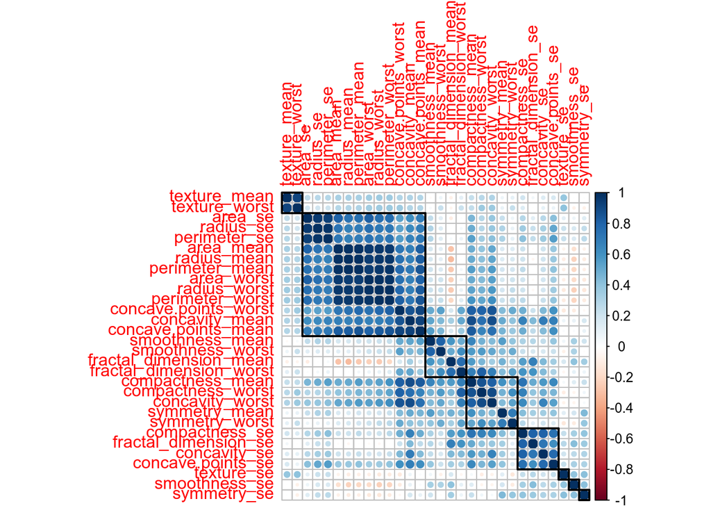

```r
# Remove the factorial column 'diagnosis' to find the correlation between numerical columns.
data_corr<- cor(cancer_data[,-1])
corrplot::corrplot(data_corr, order = "hclust", tl.cex = 1, addrect = 8)
```

It is quite clear that there are few variables that are correlated. So let’s transform the data by removing highly correlated ones using the caret package.

## Transformation of data

```r
cancer_data2<- cancer_data[,-findCorrelation(data_corr,cutoff = 0.9)]

#Number of columns for our new data frame

ncol(cancer_data2)
```

```
## [1] 21
```

So now our new data frame cancer_data2 is 10 variables shorter.

## Preprocessing of data using PCA

To get more clarity let’s do the preprocessing on data before and after transformation

1. PCA analysis on untransformed data. To do so, we will need to remove the diagnosis variable then will scale and center the variables.

```r
prepro_pca_cancerdata<- prcomp(cancer_data[,-1],scale = TRUE, center = TRUE)
summary(prepro_pca_cancerdata)
```

```
## Importance of components:
##                           PC1    PC2     PC3     PC4     PC5     PC6
## Standard deviation     3.6444 2.3857 1.67867 1.40735 1.28403 1.09880
## Proportion of Variance 0.4427 0.1897 0.09393 0.06602 0.05496 0.04025
## Cumulative Proportion  0.4427 0.6324 0.72636 0.79239 0.84734 0.88759
##                            PC7     PC8    PC9    PC10   PC11    PC12
## Standard deviation     0.82172 0.69037 0.6457 0.59219 0.5421 0.51104
## Proportion of Variance 0.02251 0.01589 0.0139 0.01169 0.0098 0.00871
## Cumulative Proportion  0.91010 0.92598 0.9399 0.95157 0.9614 0.97007
##                           PC13    PC14    PC15    PC16    PC17    PC18
## Standard deviation     0.49128 0.39624 0.30681 0.28260 0.24372 0.22939
## Proportion of Variance 0.00805 0.00523 0.00314 0.00266 0.00198 0.00175
## Cumulative Proportion  0.97812 0.98335 0.98649 0.98915 0.99113 0.99288
##                           PC19    PC20   PC21    PC22    PC23   PC24
## Standard deviation     0.22244 0.17652 0.1731 0.16565 0.15602 0.1344
## Proportion of Variance 0.00165 0.00104 0.0010 0.00091 0.00081 0.0006
## Cumulative Proportion  0.99453 0.99557 0.9966 0.99749 0.99830 0.9989
##                           PC25    PC26    PC27    PC28    PC29    PC30
## Standard deviation     0.12442 0.09043 0.08307 0.03987 0.02736 0.01153
## Proportion of Variance 0.00052 0.00027 0.00023 0.00005 0.00002 0.00000
## Cumulative Proportion  0.99942 0.99969 0.99992 0.99997 1.00000 1.00000
```

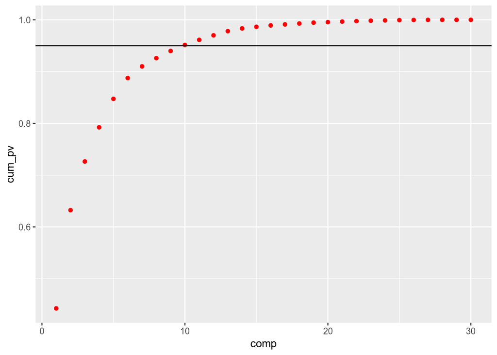

```r
# Calculate the proportion of variance explained

pca_data_var<- prepro_pca_cancerdata$sdev^2
pv_data<-pca_data_var/sum(pca_data_var)
cum_pv<- cumsum(pv_data)
pv_table<- tibble(comp= seq(1:ncol(cancer_data[-1])),pv_data,cum_pv)

#Let's plot the graph

ggplot(pv_table,aes(x=comp,y=cum_pv))+ geom_point(col= "red")+ geom_abline(intercept = 0.95,slope = 0)
```

This represents that 10 PC’s are required to explain 95% of the variance

2.PCA analysis on the Transformed data.

```r
prepro_pca_cancerdata2<- prcomp(cancer_data2,scale = TRUE, center = TRUE)
summary(prepro_pca_cancerdata2)
```

```
## Importance of components:
##                          PC1    PC2   PC3     PC4     PC5     PC6     PC7
## Standard deviation     3.053 2.1105 1.456 1.21994 1.09673 0.75004 0.66893
## Proportion of Variance 0.444 0.2121 0.101 0.07087 0.05728 0.02679 0.02131
## Cumulative Proportion  0.444 0.6561 0.757 0.82791 0.88519 0.91197 0.93328
##                            PC8     PC9    PC10    PC11    PC12    PC13
## Standard deviation     0.56454 0.53543 0.45639 0.41367 0.34423 0.26012
## Proportion of Variance 0.01518 0.01365 0.00992 0.00815 0.00564 0.00322
## Cumulative Proportion  0.94846 0.96211 0.97203 0.98018 0.98582 0.98904
##                           PC14    PC15    PC16    PC17    PC18    PC19
## Standard deviation     0.24137 0.22045 0.20547 0.17791 0.15094 0.13695
## Proportion of Variance 0.00277 0.00231 0.00201 0.00151 0.00108 0.00089
## Cumulative Proportion  0.99182 0.99413 0.99614 0.99765 0.99873 0.99963
##                           PC20    PC21
## Standard deviation     0.08384 0.02885
## Proportion of Variance 0.00033 0.00004
## Cumulative Proportion  0.99996 1.00000
```

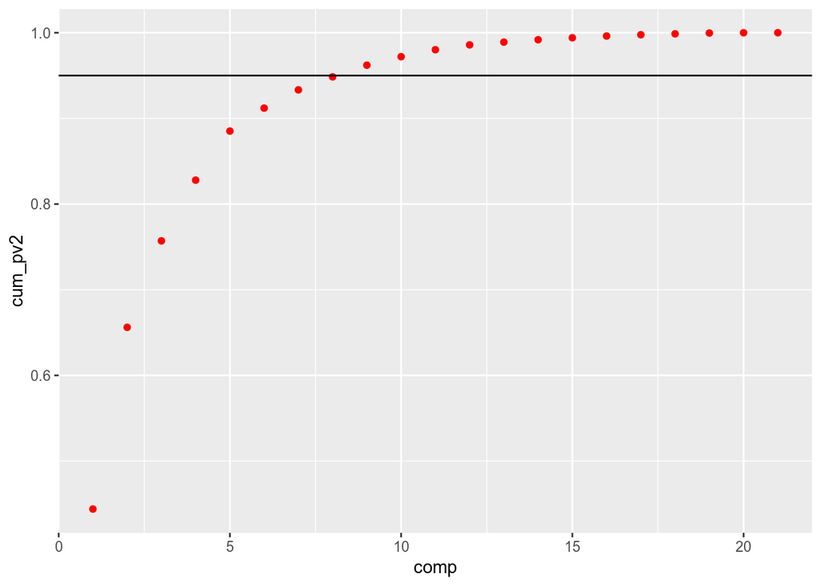

```r
# Calculate the proportion of variance explained
pca_data_var2<- prepro_pca_cancerdata2$sdev^2
pv_data2<-pca_data_var2/sum(pca_data_var2)
cum_pv2<- cumsum(pv_data2)
pv_table2<- tibble(comp= seq(1:ncol(cancer_data2)),pv_data2,cum_pv2)

#Let's plot the graph

ggplot(pv_table2,aes(x=comp,y=cum_pv2))+ geom_point(col= "red")+ geom_abline(intercept = 0.95,slope = 0)
```

Let’s Visualize which variable are the most influential on the first 2 components

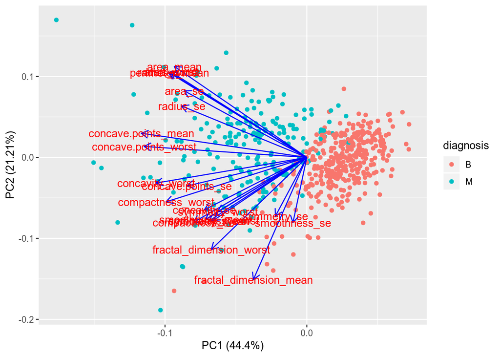

```r
autoplot(prepro_pca_cancerdata2, data = cancer_data,  colour = 'diagnosis',
                    loadings = FALSE, loadings.label = TRUE, loadings.colour = "blue")
```

## Prediction of data

```r
pred_cancerdata<- predict(prepro_pca_cancerdata2,newdata = cancer_data2)
```

Combine the removed ‘diagnosis’ column to the predicted data

```r
cancer_data2<- cbind(diagnosis= cancer_data[,1],pred_cancerdata)
#Convert the matrix to data frame
cancer_data2 = data.frame(cancer_data2)
str(cancer_data2)
```

```
## 'data.frame':    569 obs. of  22 variables:
##  $ diagnosis: num  2 2 2 2 2 2 2 2 2 2 ...
##  $ PC1      : num  -8.03 -1.94 -5 -7.52 -3.1 ...
##  $ PC2      : num  -1.24 3.49 1.26 -9.49 2.25 ...
##  $ PC3      : num  0.768 0.55 0.141 1.999 -1.639 ...
##  $ PC4      : num  1.2646 -0.0703 0.4298 2.08 0.3628 ...
##  $ PC5      : num  1.3522 0.0051 0.5155 3.1918 -1.4042 ...
##  $ PC6      : num  1.8059 -0.0175 -0.7362 1.6282 -0.7431 ...
##  $ PC7      : num  -0.5035 0.0446 -0.1259 1.102 0.4189 ...
##  $ PC8      : num  0.0707 0.1844 -0.304 -1.9912 0.3956 ...
##  $ PC9      : num  -0.147 0.749 0.324 -0.368 0.245 ...
##  $ PC10     : num  0.264 -0.183 0.647 0.912 -0.61 ...
##  $ PC11     : num  0.2776 1.2841 -0.0512 0.7995 0.4451 ...
##  $ PC12     : num  0.3542 -0.2988 -0.0154 -0.4666 0.358 ...
##  $ PC13     : num  0.802 -0.606 0.241 0.248 -0.267 ...
##  $ PC14     : num  -0.0207 0.1119 -0.2569 -0.3415 -0.2913 ...
##  $ PC15     : num  -0.5248 0.2645 0.0723 0.0625 0.147 ...
##  $ PC16     : num  -0.0823 -0.022 0.1783 0.1311 0.0702 ...
##  $ PC17     : num  0.0661 0.2693 0.1729 -0.1687 -0.2674 ...
##  $ PC18     : num  -0.1511 -0.0648 -0.0528 -0.079 0.1135 ...
##  $ PC19     : num  -0.0953 0.3092 -0.064 0.0799 -0.0309 ...
##  $ PC20     : num  -0.326 0.1029 0.1012 0.0601 0.0181 ...
##  $ PC21     : num  -0.05137 0.00725 0.00861 0.07493 -0.02083 ...
```

```r
# Convert diagnosis column into factorial
cancer_data2$diagnosis = as.factor(cancer_data2$diagnosis)
```

## Data Modeling

Create the train and test data.

```r
# Store 80% of the random dataset into the variable
cancer_data2_Index <- createDataPartition(cancer_data2$diagnosis,p= 0.8, list = FALSE)

# Assign these 80% of the data to the train dataset and rest 20% into test dataset.
cancer_data2_train <- cancer_data2[cancer_data2_Index,]
cancer_data2_test <- cancer_data2[-cancer_data2_Index,]
```

### C5.0 Model

```r
model_c50<-C5.0(diagnosis ~ ., data=cancer_data2_train,
                      trials=10,                  # creating max 10 weak learners steps
                      control = C5.0Control      # parameter control list. May specify separately
                        (
                           noGlobalPruning = FALSE,
                           CF=0.50,       # Less the value, more drastic the pruning.
                           minCases=10,   # Min cases per leaf-node
                           sample = 0.80, # Take 80% sample for training. Rest 20% used for testing
                           winnow=FALSE,            # TRUE may make it more general
                           earlyStopping=TRUE       # boosting will be stopped early
                        ))
```

#### Plot the model

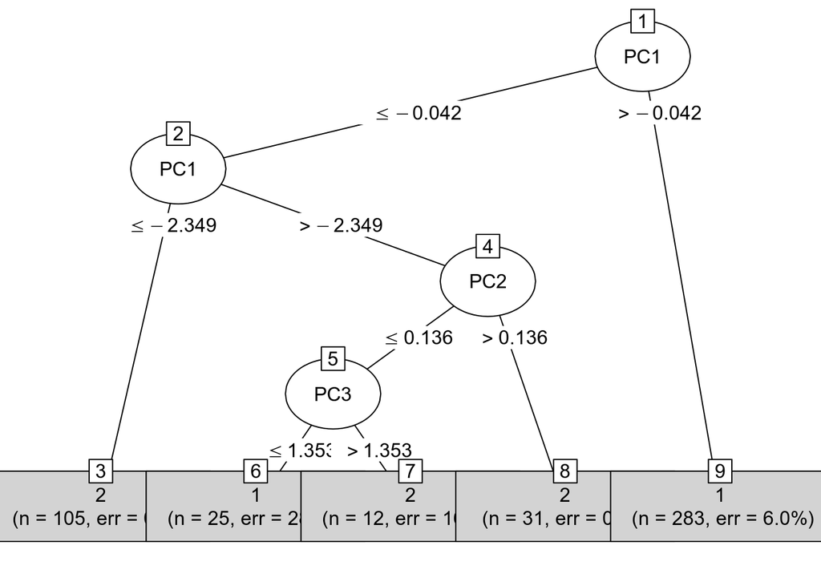

```r
plot(model_c50,type="simple",gpar = gpar(fontsize = 5), drop_terminal = T, tnex=1)
```

#### Prediction

Make predictions from the model created above

```r
predict_c50<- predict(model_c50,cancer_data2_test,type="class")

#Plot the confusion Matrix

confusionMatrix(predict_c50, cancer_data2_test$diagnosis)
```

```
## Confusion Matrix and Statistics
##
##           Reference
## Prediction  1  2
##          1 66  6
##          2  5 36
##
##                Accuracy : 0.9027
##                  95% CI : (0.8325, 0.9504)
##     No Information Rate : 0.6283
##     P-Value [Acc > NIR] : 3.429e-11
##
##                   Kappa : 0.7906
##  Mcnemar's Test P-Value : 1
##
##             Sensitivity : 0.9296
##             Specificity : 0.8571
##          Pos Pred Value : 0.9167
##          Neg Pred Value : 0.8780
##              Prevalence : 0.6283
##          Detection Rate : 0.5841
##    Detection Prevalence : 0.6372
##       Balanced Accuracy : 0.8934
##
##        'Positive' Class : 1
##
```

```r
#Draw the Crosstable

CrossTable(cancer_data2_test$diagnosis,predict_c50,prop.chisq = T,prop.c = F,prop.r = F,dnn = c("Actual Diagnosis","Predict Diagnosis"))
```

```
##
##
##    Cell Contents
## |-------------------------|
## |                       N |
## | Chi-square contribution |
## |         N / Table Total |
## |-------------------------|
##
##
## Total Observations in Table:  113
##
##
##                  | Predict Diagnosis
## Actual Diagnosis |         1 |         2 | Row Total |
## -----------------|-----------|-----------|-----------|
##                1 |        66 |         5 |        71 |
##                  |     9.528 |    16.732 |           |
##                  |     0.584 |     0.044 |           |
## -----------------|-----------|-----------|-----------|
##                2 |         6 |        36 |        42 |
##                  |    16.106 |    28.284 |           |
##                  |     0.053 |     0.319 |           |
## -----------------|-----------|-----------|-----------|
##     Column Total |        72 |        41 |       113 |
## -----------------|-----------|-----------|-----------|
##
##
```

#### Accuracy

```r
df<- data.frame(predicted=predict_c50, actual=cancer_data2_test$diagnosis)
table(df$actual, df$predicted, dnn=c("Actual","Predicted"))
```

```
##       Predicted
## Actual  1  2
##      1 66  5
##      2  6 36
```

```r
accuracy<-sum(as.character(df$actual) == as.character(df$predicted))/nrow(df)
accuracy
```

```
## [1] 0.9026549
```

### Neural Network Model

```r
model_nnet<-nnet(diagnosis ~. ,
                 data= cancer_data2_train,
                 size=8
)
```

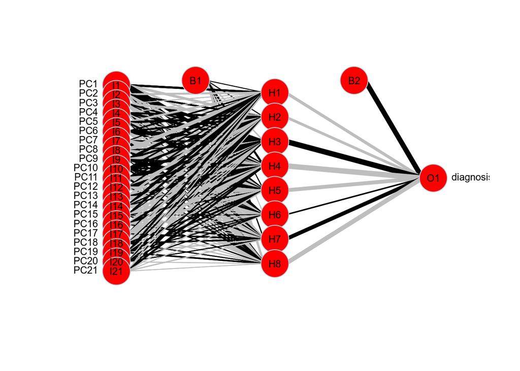

```r
# Plot a neural interpretation diagram for a neural network object
plotnet(model_nnet, cex_val =.8,max_sp=T,circle_cex=5,circle_col = 'red')
```

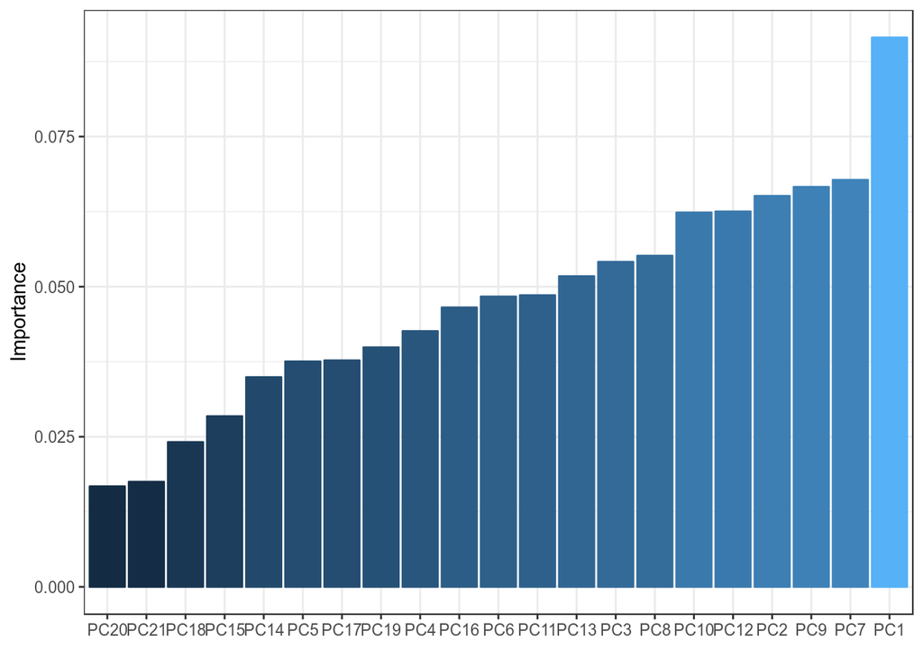

```r
#Relative importance of input variables in neural networks using Garson's algorithm
garson(model_nnet)
```

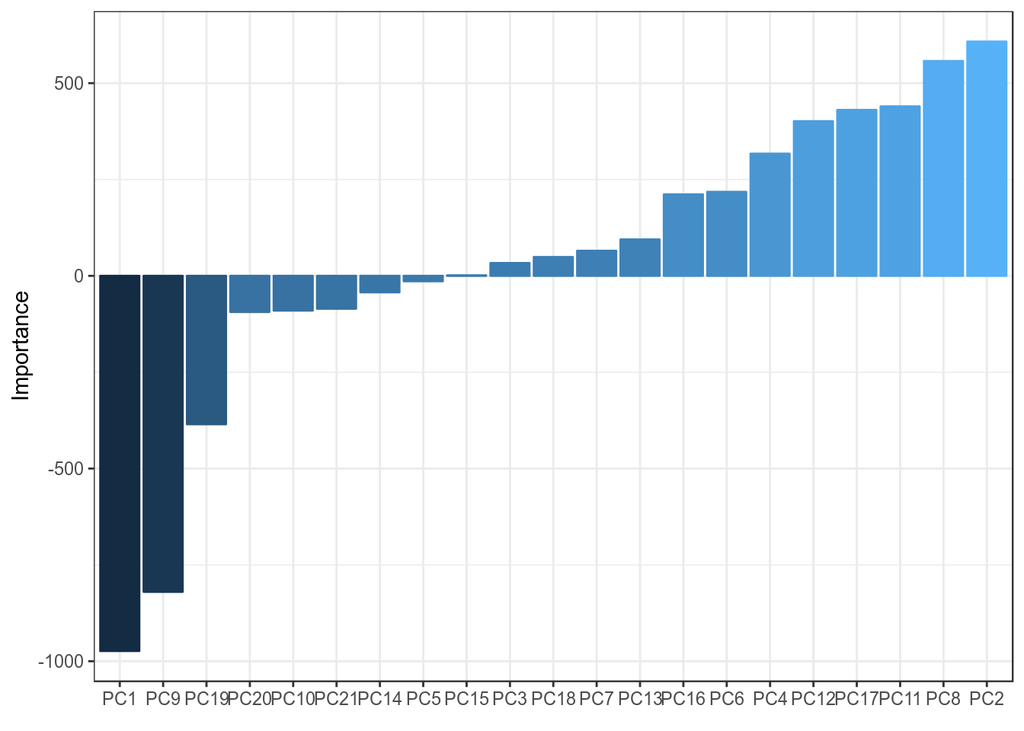

```r
olden(model_nnet)
```

Here both the positve and negative value represents relative contibutions of each connection weight among the variables

#### Predict

```r
predict_nnet<- predict(model_nnet,cancer_data2_test,type = "class")
```

#### Draw the crosstable

```r
CrossTable(cancer_data2_test$diagnosis,predict_nnet,prop.chisq = F,prop.r = F,prop.c = F,dnn =c("Actual Diagnosis","Predict Diagnosis"))
```

```
##
##
##    Cell Contents
## |-------------------------|
## |                       N |
## |         N / Table Total |
## |-------------------------|
##
##
## Total Observations in Table:  113
##
##
##                  | Predict Diagnosis
## Actual Diagnosis |         1 |         2 | Row Total |
## -----------------|-----------|-----------|-----------|
##                1 |        68 |         3 |        71 |
##                  |     0.602 |     0.027 |           |
## -----------------|-----------|-----------|-----------|
##                2 |         5 |        37 |        42 |
##                  |     0.044 |     0.327 |           |
## -----------------|-----------|-----------|-----------|
##     Column Total |        73 |        40 |       113 |
## -----------------|-----------|-----------|-----------|
##
##
```

#### Accurancy

```r
table(df$actual, df$predicted, dnn=c("Actual","Predicted"))
```

```
##       Predicted
## Actual  1  2
##      1 66  5
##      2  6 36
```

```r
accuracy<-sum(as.character(df$actual) == as.character(df$predicted))/nrow(df)
accuracy
```

```
## [1] 0.9026549
```